# Normal Random Variables

Yuanting Lu

10/08/2020

### Continuous Variable

**A continuous random variable** is one whose set of possible values is an interval.

Every continuous random variable $X$ has a curve associated with it. This curve, formally known as a **probability density function**, such that

- The total area under the curve is 1.
- The area between $x_1$ and $x_2$ is the probability $P(x_1\le X \le x_2)$ or $P(x_1< X < x_2)$.

### Uniform Distribution

A random variable is said to be a **uniform random variable** in the interval $(a, b)$ if its set of possible values is this interval and if its density curve is a horizontal line.

**Example 1.** Suppose that $X$ is a uniform random variable over the interval $(2, 5)$.

1. Draw the density function of $X$.
2. Find $P(X > 3)$.
3. Find $P(X \ge 4)$.
4. Find $P(X \le 2)$.
5. Find $P(2.5 < X < 3.5)$.

### Normal Distribution

If $X$ is a normal random variable with a mean of $\mu$ and standard deviation of $\sigma$, then we denote
$$X\sim N(\mu, \sigma^2).$$

The probability $P(X\le a)$ can be calculated by

```r
pnorm(a, mu, sigma)
```

As a result,

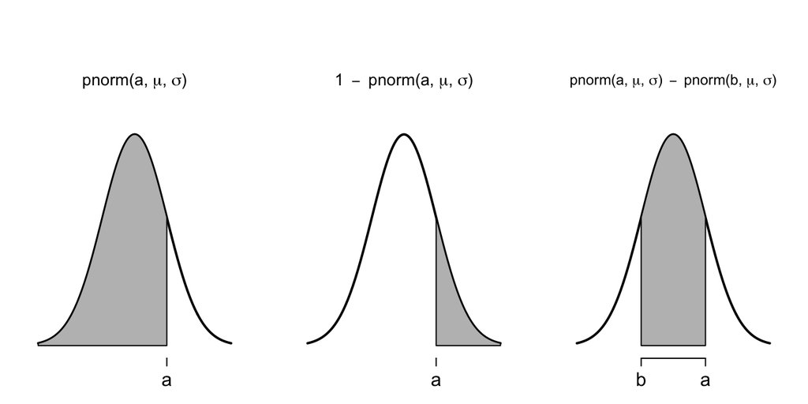

**Example 2.** IQ scores follow a normal distribution with a mean of 100 and standard deviation of 15.

1. What proportion of people have below average intelligence?
2. What proportion of people have an IQ between 80 and 120?
3. What proportion of people have an IQ more than 110?
4. What proportion of people have an IQ less than 115?

**Example 3.** Verify the Empirical Rule using normal distribution.

### Standard Normal Distribution

A **z-score** (also called a standard score) measures how far from the mean ($\mu$) a data point is, in terms of standard deviation ($\sigma$):
$$Z = \dfrac{X-\mu}{\sigma}.$$

**Example 4.** Suppose in a given year, the mean and the standard deviation of SAT scores are 1100 and 200, respectively. The mean and the standard deviation of ACT scores are 22 and 5, respectively. Which of the two scores has a higher z-score, an SAT score of 1400 or an ACT score of 33?

The z-scores of a normal standard distribution $N(\mu, \sigma^2)$, follows a **standard normal distribution $N(0, 1)$**, whose mean is 0 and standard deviation is 1.

The command `pnorm(a, 0, 1)` is the same as `pnorm(a)`, i.e., if the mean and standard deviation are not input, by default, R sets $\mu=0$ and $\sigma = 1$.

**Example 5.** Suppose $\mu=1100$ and $\sigma=200$ in an SAT test. Find the percentile of the SAT score of 1450.

To calculate the z-scores in a standard normal distribution, i.e., $P(X<z)=p$

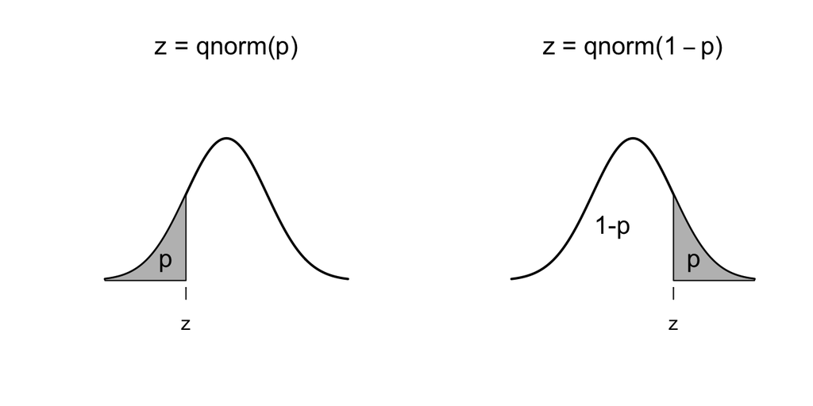

```r
qnorm(p)
```

**Example 6.** Continue with Example 2.

1. What is the 80th percentile of IQ?
2. Suppose that you wanted to hire only people who are in the top 10% of the IQ scale. What would the cutoff be?

**Example 7.** The waiting time at a fast food restaurant drive through window is normally distributed with mean 139 seconds and standard deviation of 29 seconds. The restaurant wants to introduce a policy that customer who has to wait more than a certain amount of time does not have to pay. Management plans to give away no more than 1% of its customers free meals. What time would you recommend the restaurant advertises as the maximum wait time before a free meal is awarded?

Conventionally, the subscript $\alpha$ is used to indicate the probability of $Z$ larger than the z-score is $\alpha$.

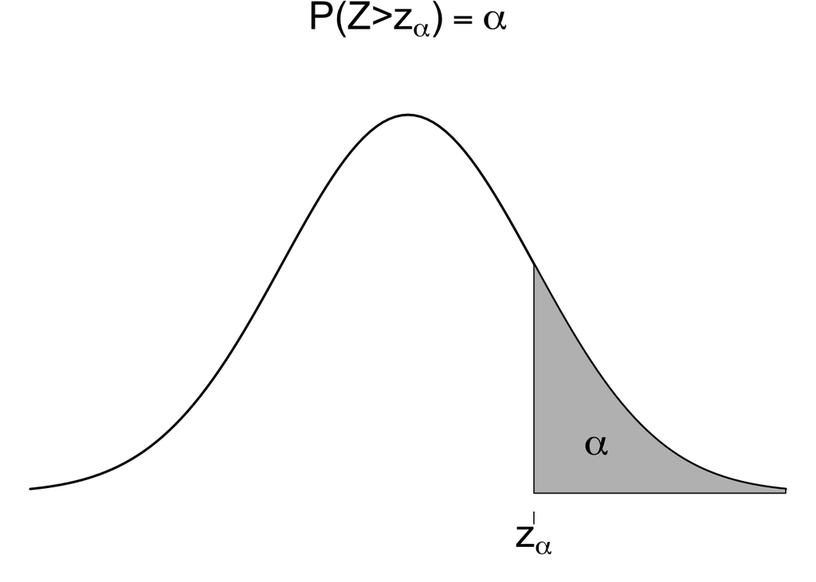

**Example 8.** Find $z_{0.05}, z_{0.025}$, and $z_0.005$.